# Intro to DS - Linear Model Part I

Folaranmi Adeyeri

2022-10-20

# Linear models - Quantitative Regressors

This uses `bikedata.csv` on this GitHub repo.

### Question 1

**Import the data and name it `bikeorig`. Remove `Date`, `Casual_Users`, and `Registered_Users` from the dataset and save it as a new data frame named `bike`. How many variables are in `bike`? How many of them are imported as `int`? Feel free to rename longer variable names into shorter ones for convenience.**

There are 11 variables. 9 variables are imported as integers in bike

```r
library(tidyverse)

bikeorig = data.frame(read.csv("bikedata.csv"))

#Get selected columns to then use for removal for columns
selectedRows <- names(bikeorig) %in% c("Date", "Casual.Users", "Registered.Users")
bike <- bikeorig[!selectedRows]

#Count the number of columns to get the number of variables
ncol(bike)
```

```
## [1] 11
```

```r
str(bike)
```

```
## 'data.frame':    17379 obs. of  11 variables:
##  $ Season             : int  4 4 4 4 4 4 4 4 4 4 ...
##  $ Hour               : int  0 1 2 3 4 5 6 7 8 9 ...
##  $ Holiday            : int  0 0 0 0 0 0 0 0 0 0 ...
##  $ Day.of.the.Week    : int  6 6 6 6 6 6 6 6 6 6 ...
##  $ Working.Day        : int  0 0 0 0 0 0 0 0 0 0 ...
##  $ Weather.Type       : int  1 1 1 1 1 2 1 1 1 1 ...
##  $ Temperature.F      : num  36.6 34.9 34.9 36.6 36.6 36.6 34.9 33.1 36.6 43.5 ...
##  $ Temperature.Feels.F: num  37.4 35.6 35.6 37.4 37.4 33.8 35.6 33.8 37.4 44.6 ...
##  $ Humidity           : int  81 80 80 75 75 75 80 86 75 76 ...
##  $ Wind.Speed         : int  0 0 0 0 0 6 0 0 0 0 ...
##  $ Total.Users        : int  16 40 32 13 1 1 2 3 8 14 ...
```

```r
colnames(bike)[4:8] = c("Day", "Workday", "Weather", "Temp", "Feels_Like")
```

### Question 2

**Select the subset with `Hour` equal 16 only and name the new data frame `bike16`. These are the afternoon rush hour data. How many observations are there?**

There are 730 observations

```r
bike16 <- subset(bike, Hour == 16)
count(bike16)
```

```
##     n
## 1 730
```

### Question 3

**Before building any models, we should make sure the variables are set up properly. Which ones should be recorded as categorical? Convert them now before proceeding to the model building.**

We will go ahead and answer this question for you…

```r
bike_final <- bike16
bike_final$Season <- factor(bike16$Season)
bike_final$Holiday <- factor(bike16$Holiday)
bike_final$Day <- factor(bike16$Day)
bike_final$Workday <- factor(bike16$Workday)
bike_final$Weather <- factor(bike16$Weather)
str(bike_final)
```

[output not shown]

The above code converts the following variables into categorical (factor):  
`Season`, `Holiday`, `Day`, `Workday`, and `Weather`. Notice that the data frame `bike16` still has all variables numerical, while the data frame `bike_final` has the categorical columns that we just converted.

### Question 4

**Make a `pairs()` plot with all the variables (quantitative and qualitative) in the `bike_final` dataset.**

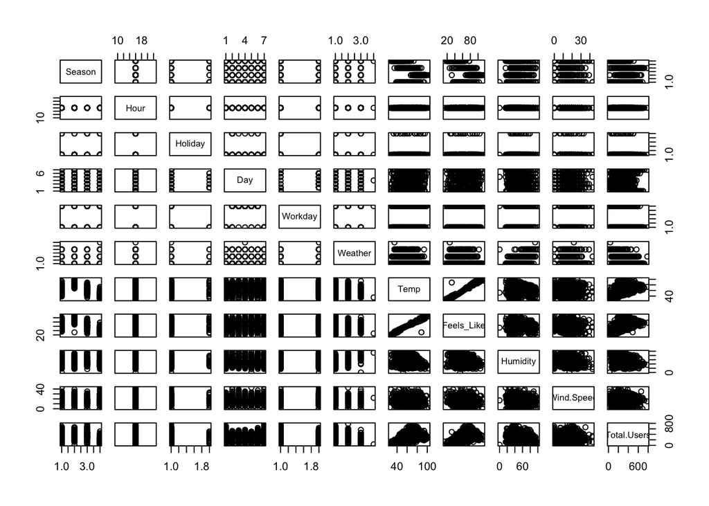

```r
library(lattice)
pairs(bike_final)
```

Note: While the `cor()` function does not accept categorical variables (and therefore we cannot use it for `corrplot()`), the `lattice::pairs()` function does not complain about categorical columns. We can still use it to get a visual distribution of data values from it.

### Question 5

**Make a `corrplot()` with only the numerical variables in the `bike_final` dataset.**

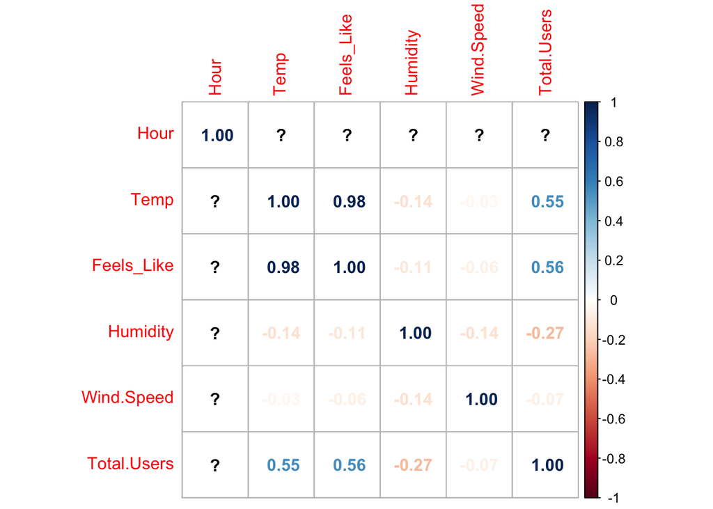

```r
library('corrplot')

numericalBike <- select_if(bike_final, is.numeric)
correlation = cor(numericalBike)
corrplot(correlation, method = 'number')
```

Note: correlation functions will not work with categorical/factor variables. You can either subset the data frame to only numerical variables first, then create the correlation matrix to plot. Or you can create the correlation matrix from `bike16`, then select out the portion of the matrix that you want. Use options that does a good job showing the relationships between different variables.

### Question 6

**Using only the numerical variables from the `bike_final` dataset, build a linear model with 1 independent variable to predict the `Total Users`. Choose the variable with the strongest correlation coefficient. Comment on the coefficient values, their p-values, and the multiple R-squared value.**

```r
linearData1 <- lm(Total.Users ~ Temp, data = numericalBike)
summary(linearData1)
```

```
##
## Call:
## lm(formula = Total.Users ~ Temp, data = numericalBike)
##
## Residuals:
##    Min     1Q Median     3Q    Max
## -319.1  -90.9   -5.1   77.1  431.6
##
## Coefficients:
##             Estimate Std. Error t value Pr(>|t|)
## (Intercept)   -0.154     18.079   -0.01     0.99
## Temp           4.828      0.270   17.85   <2e-16 ***
## ---
## Signif. codes:  0 '***' 0.001 '**' 0.01 '*' 0.05 '.' 0.1 ' ' 1
##
## Residual standard error: 124 on 728 degrees of freedom
## Multiple R-squared:  0.304,  Adjusted R-squared:  0.303
## F-statistic:  319 on 1 and 728 DF,  p-value: <2e-16
```

### Question 7

**Next, add a second variable to the model. Choose the variable with the next strongest correlation, but avoid using obviously collinear variables (`TempF` and `TempFF` for example). Comment on the coefficient values, their p-values, and the multiple R-squared value.**

```r
library(car)

linearData2 <- lm(Total.Users ~ Temp + Wind.Speed, data = numericalBike)

#To check for the correlation to use
vif(linearData2)
```

```
##       Temp Wind.Speed
##          1          1
```

```r
summary(linearData2)
```

```
##
## Call:
## lm(formula = Total.Users ~ Temp + Wind.Speed, data = numericalBike)
##
## Residuals:
##    Min     1Q Median     3Q    Max
## -302.8  -92.7   -4.6   76.8  431.0
##
## Coefficients:
##             Estimate Std. Error t value Pr(>|t|)
## (Intercept)   14.283     20.373    0.70     0.48
## Temp           4.815      0.270   17.81   <2e-16 ***
## Wind.Speed    -0.853      0.557   -1.53     0.13
## ---
## Signif. codes:  0 '***' 0.001 '**' 0.01 '*' 0.05 '.' 0.1 ' ' 1
##
## Residual standard error: 124 on 727 degrees of freedom
## Multiple R-squared:  0.307,  Adjusted R-squared:  0.305
## F-statistic:  161 on 2 and 727 DF,  p-value: <2e-16
```

Note: When you have the model, check the VIF values. If the VIF is higher than 5, discard this model, and try the variable with the next strongest correlation until you find one that works (ideally with VIF<5, or if you have to, allow VIF up to 10).

### Question 8

**We will try one more time as in the previous question, to add a third numeric variable in our model.**

```r
linearData3 <- lm(Total.Users ~ Temp + Wind.Speed + Humidity, data = numericalBike)

#To check for the correlation to use
vif(linearData3)
```

```
##       Temp Wind.Speed   Humidity
##       1.02       1.02       1.04
```

```r
summary(linearData3)
```

```
##
## Call:
## lm(formula = Total.Users ~ Temp + Wind.Speed + Humidity, data = numericalBike)
##
## Residuals:
##    Min     1Q Median     3Q    Max
## -313.7  -87.5   -7.5   75.8  410.4
##
## Coefficients:
##             Estimate Std. Error t value Pr(>|t|)
## (Intercept)  121.044     25.199    4.80  1.9e-06 ***
## Temp           4.552      0.265   17.17  < 2e-16 ***
## Wind.Speed    -1.385      0.546   -2.54    0.011 *
## Humidity      -1.640      0.240   -6.83  1.8e-11 ***
## ---
## Signif. codes:  0 '***' 0.001 '**' 0.01 '*' 0.05 '.' 0.1 ' ' 1
##
## Residual standard error: 120 on 726 degrees of freedom
## Multiple R-squared:  0.349,  Adjusted R-squared:  0.346
## F-statistic:  129 on 3 and 726 DF,  p-value: <2e-16
```

### Question 9

**For the three variable model you found in Q8, find the confidence intervals of the coefficients.**

```r
#Using cor.test to find the confidence interval of the Temp variable
tempInter <- cor.test(numericalBike$Total.Users, numericalBike$Temp)
tempInter
```

```
##
##  Pearson's product-moment correlation
##
## data:  numericalBike$Total.Users and numericalBike$Temp
## t = 18, df = 728, p-value <2e-16
## alternative hypothesis: true correlation is not equal to 0
## 95 percent confidence interval:
##  0.499 0.600
## sample estimates:
##   cor
## 0.552
```

```r
#Using cor.test to find the confidence interval of the Wind.Speed variable
speedInter <- cor.test(numericalBike$Total.Users, numericalBike$Wind.Speed)
speedInter
```

```
##
##  Pearson's product-moment correlation
##
## data:  numericalBike$Total.Users and numericalBike$Wind.Speed
## t = -2, df = 728, p-value = 0.08
## alternative hypothesis: true correlation is not equal to 0
## 95 percent confidence interval:
##  -0.13722  0.00729
## sample estimates:
##     cor
## -0.0653
```

```r
#Using cor.test to find the confidence interval of the Humidity variable
humidInter <- cor.test(numericalBike$Total.Users, numericalBike$Humidity)
humidInter
```

```
##
##  Pearson's product-moment correlation
##
## data:  numericalBike$Total.Users and numericalBike$Humidity
## t = -8, df = 728, p-value = 1e-13
## alternative hypothesis: true correlation is not equal to 0
## 95 percent confidence interval:
##  -0.337 -0.202
## sample estimates:
##    cor
## -0.271
```

### Question 10

**Use ANOVA to compare the three different models you found. Interpret the results. What conclusion can you draw?**

Model 2 has a p-value of 0.11 which means there is no statistically significant difference which means we are goin to accept the null hypothesis and model 3 with the three variables has a p-value of 1.8x10-11 which means it has a statistically significant difference which mean we are going reject the null hypothesis

```r
#This returned the comparison between the models
anovaRes <- anova(linearData1,linearData2,linearData3)
anovaRes
```

```
## Analysis of Variance Table
##
## Model 1: Total.Users ~ Temp
## Model 2: Total.Users ~ Temp + Wind.Speed
## Model 3: Total.Users ~ Temp + Wind.Speed + Humidity
##   Res.Df      RSS Df Sum of Sq     F  Pr(>F)
## 1    728 11209390
## 2    727 11173323  1     36068  2.49    0.11
## 3    726 10499038  1    674285 46.63 1.8e-11 ***
## ---
## Signif. codes:  0 '***' 0.001 '**' 0.01 '*' 0.05 '.' 0.1 ' ' 1
```

```r
str(anovaRes)
```

```
## Classes 'anova' and 'data.frame':    3 obs. of  6 variables:
##  $ Res.Df   : num  728 727 726
##  $ RSS      : num  11209390 11173323 10499038
##  $ Df       : num  NA 1 1
##  $ Sum of Sq: num  NA 36068 674285
##  $ F        : num  NA 2.49 46.63
##  $ Pr(>F)   : num  NA 1.15e-01 1.82e-11
##  - attr(*, "heading")= chr [1:2] "Analysis of Variance Table\n" "Model 1: Total.Users ~ Temp\nModel 2: Total.Users ~ Temp + Wind.Speed\nModel 3: Total.Users ~ Temp + Wind.Speed + Humidity"
```

```r
xkabledply(anovaRes, title = "ANOVA comparison between the models")
```

ANOVA comparison between the models

| Res.Df | RSS | Df | Sum of Sq | F | Pr(>F) |
| --- | --- | --- | --- | --- | --- |
| 728 | 11209390 | NA | NA | NA | NA |
| 727 | 11173323 | 1 | 36068 | 2.49 | 0.115 |
| 726 | 10499038 | 1 | 674285 | 46.63 | 0.000 |